# SEA-AD multiregional progression, tissue response and longitudinal cognitive phenotypes

Released Global/Local CPS against conventional staging, MG4 and NeuN in regional tissue, and four-domain cognitive level and decline in ACT

## 1. Scientific questions and cohort

This notebook links global AD progression, regional pathological involvement and cellular tissue response to longitudinal cognitive phenotypes. Morphology is still being processed.

Its first pass established four results from direct multiregional QNP:

- MG4 is mainly donor-level and follows donor-wide tau.
- Regional NeuN is weakly lower where regional tau is higher.
- Executive decline behaves differently from memory decline.
- Multiregional tau accounts for part of the cognitive “discordance” left by the MTG-fitted CPS.

Those results are kept (Sections 3 and 6). This amended version moves the progression representation onto the **released multiregion progression scores**, and it characterizes **all four cognitive domains**.

1. **Disease heterogeneity.** How heterogeneous is quantitative progression within Braak and ADNC categories? How does local involvement vary among donors at comparable global progression? Which anatomical patterns appear across the available regions?
2. **Longitudinal cognitive phenotypes.** How do terminal CASI, the global slope, and the level and rate of memory, executive, language and visuospatial function relate to global versus anatomically matched local pTau progression?
3. **Tissue response.** Does MG4 follow global or region-specific pTau progression? Does regional NeuN vary with local pTau progression? Does MG4 carry tissue-integrity information at comparable local pathology?

Everything is cross-sectional postmortem tissue plus antemortem cognition. No association below is causal, establishes temporal order or mediation, or measures circuit function.

**Progression source and definitions.** `Global_and_Local_CPS.20260105.csv` from the multiregion release is used as released. Its columns are `CPS_Global`, `CPS_Global_pTau`, `CPS_Global_ABeta`, `CPS_Local`, `CPS_Local_pTau` and `CPS_Local_ABeta`.

- **Not re-derived.** Nothing is re-estimated, averaged across regions, or combined into a new score.
- **Global and local are not independent exposures.** They are never entered as if they were, and local is not treated as a residual from global.
- **Distinct from notebook 04’s CPS.** `CPS_Global` is not `SpecimenMetadata.csv`’s `Continuous Pseudo-progression Score` (the Gabitto MTG CPS; notebook 01). The Gabitto-CPS analyses from this notebook’s first pass are kept for reference in Section 6 and are not repeated.

**Inputs, all reused unchanged:**

| Block | Source | Defined in |
| --- | --- | --- |
| Released Global/Local CPS (all; Aβ; pTau) | `Global_and_Local_CPS.20260105.csv` | release; grid checked in notebook 01 |
| Braak, ADNC, co-pathology, `Severely Affected Donor` | donor-metadata workbook | notebooks 00, 04 |
| Regional QNP (AT8, 6E10, NeuN, GFAP; Grey matter) | `qnp_primary_long()`, June 2026 workbook | notebook 00 |
| MG4 and astrocyte activation, competitive scores | `molecular_state_analysis_table.csv` | notebook 03 |
| Terminal CASI | `Last CASI Score`, `Interval from last CASI in months` | notebook 04 |
| Harmonized longitudinal cognition and released slopes | `sea-ad_cohort_harmonized_cognitive_scores_20241213.xlsx` | notebook 00 |
| snRNA-seq nuclei per library (severely-affected check only) | `supertype_abundances_by_library.csv`, `row_state_scores.csv` | notebooks 01–02 |

Nothing was downloaded, rescored, re-aggregated or re-normalized.

**Not available locally:**

- The Kavli research strategy, the ACT DUA specifications, the reuse literature census and any resilience survey.
- `CASI_bifactor_scores`.
- A codebook for the released slopes, or their standard errors.

### Cohort and coverage

Cohorts. Rows in the tissue sets are donor × ROI and are never counted as donors. Cognition is ACT-only throughout; ADRC donors enter only disease and tissue analyses. No analysis requires every region.

| Analysis set | Donors | Donor × ROI rows | Unit | Used in |
| --- | --- | --- | --- | --- |
| All SEA-AD donors | 84 (ACT 69, ADRC 15; severely affected 11) | – | donor | §2 |
| Released Global CPS (all, Aβ, pTau) | 84 | – | donor | §2–5 |
| Released Local CPS (all, Aβ, pTau) | 84 | MEC 83 · HIP 84 · FI 43 · STG 84 · ITG 43 · MTG 84 · DFC 84 · AnG 43 · V1C 84 | donor × ROI | §2 (all regions); §3–5 |
| Regional QNP (AT8, 6E10, NeuN, GFAP), core | 83 in all three ROIs | MTG 84 · DFC 84 · MEC 83 | donor × ROI | §3 |
| MG4 competitive score, all regions | 77 in all three core ROIs | MEC 80 · HIP 40 · FI 41 · STG 43 · ITG 43 · MTG 84 · DFC 80 · AnG 43 · V1C 43 | donor × ROI | §3 |
| Tissue set, primary (core QNP complete; MG4 where present) | 83 | 242 rows | donor × ROI | §3 |
| Tissue set, balanced (QNP + MG4 + astrocyte in all three) | 76 (ACT 62) | 228 rows | donor × ROI | §3, §5 |
| Terminal CASI | 69 (all ACT) | – | donor | §4–5 |
| Harmonized cognition, ACT | 69; visits 7 [6–9]; all four domains and all five released slopes | – | donor × visit | §4–5 |
| Harmonized cognition, ADRC | 12 with visits; 0 with released slopes | – | donor × visit | not modelled |

**Timing of the ACT cognitive data** (whole years; median [IQR]):

- follow-up spans 13 [10–16] years;
- the first visit falls 17 [13–19] years before death;
- the last harmonized visit falls 2 [2–3] years before death (at most 10);
- the last CASI falls 2.1 [1.2–3.4] years before death.

**Coverage decisions.**

- **Regions.** Local CPS covers nine regions. AnG, FI and ITG were profiled only in the 43 “AD-spectrum” donors, so they enter region-wise and are never forced into a complete panel.
- **Donor-wide direct QNP.** Always the MTG/DFC/MEC mean, from donors with QNP in all three. H20.33.034 lacks MEC QNP and is left out of that decomposition only.

## 2. Disease heterogeneity: conventional staging and released progression

**Staging as the reference.** Braak stage and ADNC serve as the conventional frame; neither is read as disease time. Every quantity in this section is descriptive:

- the spread of `CPS_Global_pTau` inside each stage;
- the spread of `CPS_Local_pTau` in each region among donors in the same `CPS_Global_pTau` tertile;
- each region’s median local pTau as global progression rises, which gives its anatomical ordering.

Released Global pTau CPS within conventional categories, all 84 donors. Descriptive only.

| Staging | Category | Donors | Global pTau CPS, median [IQR] | Range | Global CPS, median |
| --- | --- | --- | --- | --- | --- |
| Braak | 0 | 2 | 0.02 [0.01–0.03] | 0.00–0.04 | 0.10 |
| Braak | II | 4 | 0.12 [0.04–0.21] | 0.03–0.25 | 0.24 |
| Braak | III | 6 | 0.11 [0.08–0.14] | 0.08–0.15 | 0.32 |
| Braak | IV | 23 | 0.25 [0.17–0.37] | 0.04–0.47 | 0.39 |
| Braak | V | 34 | 0.62 [0.54–0.75] | 0.18–0.97 | 0.77 |
| Braak | VI | 15 | 0.90 [0.80–0.94] | 0.53–1.00 | 0.90 |
| ADNC | Not AD | 9 | 0.10 [0.04–0.18] | 0.03–0.42 | 0.15 |
| ADNC | Low | 12 | 0.22 [0.09–0.27] | 0.00–0.44 | 0.21 |
| ADNC | Intermediate | 21 | 0.25 [0.16–0.40] | 0.08–0.64 | 0.50 |
| ADNC | High | 42 | 0.75 [0.60–0.83] | 0.31–1.00 | 0.83 |

Released local pTau CPS by region, ordered by overall median. Global tertiles are over all 84 donors. Tertiles pool different donors per region (AnG, FI, ITG: the 43 AD-spectrum donors only). Descriptive.

| Region | Donors | ρ local vs Global pTau | Median local pTau by Global pTau tertile (low / mid / high) | IQR within tertile (low / mid / high) | ρ local pTau vs direct AT8 | ρ local Aβ vs direct 6E10 |
| --- | --- | --- | --- | --- | --- | --- |
| MEC | 83 | 0.82 | 0.59 / 0.81 / 0.88 | 0.13 / 0.12 / 0.08 | 0.99 | 1.00 |
| HIP | 84 | 0.79 | 0.46 / 0.66 / 0.70 | 0.13 / 0.09 / 0.05 | 1.00 | 1.00 |
| FI | 43 | 0.91 | 0.10 / 0.57 / 0.83 | 0.19 / 0.25 / 0.22 | 0.99 | 1.00 |
| STG | 84 | 0.92 | 0.02 / 0.43 / 0.67 | 0.04 / 0.26 / 0.11 | 1.00 | 0.99 |
| ITG | 43 | 0.86 | 0.13 / 0.53 / 0.71 | 0.17 / 0.21 / 0.10 | 1.00 | 0.99 |
| MTG | 84 | 0.91 | 0.07 / 0.38 / 0.62 | 0.12 / 0.24 / 0.11 | 1.00 | 1.00 |
| DFC | 84 | 0.79 | 0.22 / 0.25 / 0.66 | 0.16 / 0.14 / 0.24 | 1.00 | 1.00 |
| AnG | 43 | 0.89 | 0.02 / 0.27 / 0.69 | 0.10 / 0.24 / 0.27 | 0.98 | 1.00 |
| V1C | 84 | 0.90 | 0.00 / 0.06 / 0.47 | 0.00 / 0.16 / 0.43 | 0.97 | 1.00 |

**Reading.**

- **Within staging, progression is heterogeneous.** Global pTau CPS rises with Braak stage (ρ 0.87) and ADNC (ρ 0.84), but the categories overlap widely. Of the 34 Braak V donors, 6 sit below the highest Braak IV value and 26 above the lowest Braak VI value. Among the 42 High-ADNC donors, 13 sit below the highest Intermediate value. Braak V and High ADNC each span most of the global pTau range.
- **At comparable global progression, local involvement still varies.** Local and global pTau correlate at ρ 0.79–0.92 across regions. In the middle global tertile, the local pTau IQR is 0.09–0.26 on a 0–1 scale. It is widest in the neocortical association regions reached at mid-stage (STG, FI, AnG), where donors of the same global stage differ most in how far tau has spread.
- **Anatomical pattern.** At low global progression, local pTau is already highest in MEC and HIP (medians 0.59 and 0.46), while V1C is essentially uninvolved until the high tertile. That is the expected medial-temporal → association-cortex → primary-cortex sequence. The two neocortical core regions differ in shape: DFC already carries low-level pTau at low global stage (median 0.22 vs MTG 0.07) but rises mainly in the high tertile, whereas MTG rises steadily through mid-stage.
- **What the released local scores are.** Local pTau CPS correlates with direct AT8 at ρ ≥ 0.97 in every region, and local Aβ CPS with direct 6E10 at ρ ≥ 0.99. In rank terms they are the direct stain measurements placed on a common progression scale, not independent observations. For the same reason, direct QNP and CPS are never entered as separate exposures of one pathology in the same model.
- **Global pTau vs global CPS vs Gabitto CPS.** `CPS_Global` correlates with the Gabitto MTG CPS at ρ 0.84, and global pTau with global Aβ at ρ 0.70. The three are related but distinct released quantities.

## 3. Tissue response: MG4, NeuN and regional pathology

### 3.1 Direct QNP decomposition (first pass, retained)

Every regional measure is split into a **donor-wide** mean over MTG, DFC and MEC and a **regional deviation** from it. The fit is Mundlak within/between; the within-donor coefficient equals the donor fixed-effects estimate.

- **QNP measures:** within-ROI normal scores.
- **MG4 and astrocyte activation:** in pooled within-ROI SD units.
- **Intervals:** 2000-resample donor-cluster bootstrap. (`nlme` and `lme4` are not installed.)

**Direct-QNP state model table**

State ~ ROI + donor-wide and regional-deviation AT8 and 6E10 (SD of state per SD of pathology; donor-cluster bootstrap 95% CI). Primary: 83 donors, 242 rows; balanced: 76 donors, 228 rows.

| State | Model | AT8, donor-wide | AT8, regional deviation | 6E10, donor-wide | 6E10, regional deviation | DFC vs MTG | MEC vs MTG |
| --- | --- | --- | --- | --- | --- | --- | --- |
| MG4 | Primary (all rows) | +0.37 [+0.09, +0.66] | +0.14 [-0.03, +0.30] | +0.07 [-0.19, +0.32] | -0.12 [-0.32, +0.08] | -0.25 [-0.43, -0.07] | +0.16 [-0.08, +0.40] |
| MG4 | Balanced donors | +0.30 [+0.02, +0.61] | +0.15 [-0.00, +0.29] | +0.10 [-0.15, +0.35] | -0.08 [-0.28, +0.09] | -0.21 [-0.39, -0.04] | +0.17 [-0.07, +0.40] |
| MG4 | Log-scale pathology | +0.26 [+0.02, +0.52] | +0.17 [+0.01, +0.31] | +0.20 [-0.03, +0.42] | -0.26 [-0.68, +0.11] | -0.25 [-0.43, -0.07] | +0.16 [-0.07, +0.39] |
| Astrocyte activation | Primary (all rows) | +0.35 [+0.13, +0.59] | +0.00 [-0.14, +0.16] | -0.09 [-0.35, +0.15] | -0.22 [-0.48, +0.03] | -0.11 [-0.28, +0.06] | +0.51 [+0.30, +0.71] |

### 3.2 MG4 against released global and local pTau progression

Three quantities on the same donor × ROI rows, each a separate model rather than one joint model of global and local:

MG4 against released pTau progression; donor-cluster bootstrap 95% CI. Core: 244 rows, 84 donors; all regions: 497 rows (MEC 80 · HIP 40 · FI 41 · STG 43 · ITG 43 · MTG 84 · DFC 80 · AnG 43 · V1C 43), 84 donors.

| Quantity | Core ROIs | All regions |
| --- | --- | --- |
| (a) Global pTau, SD per SD | +0.36 [+0.20, +0.51] | +0.37 [+0.19, +0.54] |
| (b) Local pTau pooled, SD per SD | +0.46 [+0.26, +0.65] | +0.39 [+0.19, +0.57] |
| (c) Local pTau within donor, SD per SD | +0.16 [-0.08, +0.37] | -0.00 [-0.13, +0.14] |
| R²(b) − R²(a) | -0.01 [-0.05, +0.02] | -0.03 [-0.07, -0.00] |

**Reading.** MG4 follows **global** pTau progression:

- **Global:** +0.36 [+0.20, +0.51] SD per SD in the core ROIs; +0.37 [+0.19, +0.54] across all regions.
- **Local, pooled:** fits MG4 no better (R² difference -0.01 [-0.05, +0.02]; all regions -0.03 [-0.07, -0.00]).
- **Local, within donor:** a donor’s more-involved regions do not carry clearly more MG4 (+0.16 [-0.08, +0.37]; all regions -0.00 [-0.13, +0.14]).

This reproduces the direct-QNP result of 3.1 on the released progression scale. MG4 is predominantly a donor-level response that scales with global pTau stage, and only weakly, if at all, a regional one.

### 3.3 Regional NeuN, local pTau progression and MG4

NeuN is a direct QNP measurement (within-ROI normal score of NeuN-positive cells per area). It is related to local pTau through the **pTau-specific** released score and through direct AT8, in separate models, never jointly.

`CPS_Local_pTau` is released as pTau-specific. Its construction is not documented locally, but it tracks direct AT8 at ρ ≥ 0.97 in every region (Section 2). Its correlation with NeuN matches that of direct AT8, which gives no sign that NeuN is among its inputs. The combined `CPS_Local` and the Gabitto CPS are not used with NeuN, since they may contain it.

**Models, donor fixed effects throughout:**

- **Within-donor coupling:** `NeuN ~ ROI + local pTau + donor`.
- **MG4 at comparable local pathology:** `NeuN ~ ROI + local pTau + MG4 + donor`.
- **First-pass direct-AT8 model**, for comparison: the Mundlak model with donor-wide and regional AT8 and MG4, on balanced donors.

NeuN (within-ROI normal score) models, SD of NeuN per SD of predictor; donor-cluster bootstrap 95% CI. Fixed-effects rows: 83 donors, 242 rows (core ROIs with MG4); first-pass Mundlak rows: balanced donors. Severely affected donors: 11.

| Term | All donors | Without the 2 NeuN-floor donors | Without all severely affected donors |
| --- | --- | --- | --- |
| Local pTau CPS → NeuN (within donor) | -0.13 [-0.33, +0.08] | -0.12 [-0.33, +0.10] | -0.15 [-0.37, +0.09] |
| MG4 → NeuN at comparable local pTau CPS | +0.09 [-0.06, +0.23] | +0.09 [-0.05, +0.23] | +0.12 [-0.05, +0.27] |
| MG4 → NeuN at comparable direct AT8 | +0.09 [-0.06, +0.23] | +0.09 [-0.06, +0.23] | +0.12 [-0.06, +0.27] |
| Direct AT8 deviation → NeuN (first pass) | -0.13 [-0.27, +0.01] | -0.13 [-0.27, +0.00] | -0.14 [-0.30, +0.01] |
| MG4 deviation → NeuN (first pass) | +0.15 [+0.01, +0.26] | +0.15 [-0.01, +0.28] | +0.17 [+0.01, +0.30] |

**Reading.**

- **NeuN and local pTau progression.** Within donors, NeuN is lower where local pTau progression is higher (-0.13 [-0.33, +0.08] SD per SD), and the interval reaches zero. Direct AT8 gives the same result (-0.13 [-0.27, +0.01]). It is a modest, imprecise coupling, the same on both pathology representations.
- **MG4 at comparable local pathology.** It adds at most weak information:
  - at comparable local pTau CPS: +0.09 [-0.06, +0.23];
  - at comparable direct AT8: +0.09 [-0.06, +0.23];
  - the first-pass regional-deviation estimate: +0.15 [+0.01, +0.26].

  The direction is consistent (relatively MG4-high regions have slightly higher NeuN), but only the first-pass Mundlak interval clears zero. It does so barely, and not once the two NeuN-floor donors are removed (+0.15 [-0.01, +0.28]). It is not evidence that MG4 preserves neurons.

### 3.4 Supporting check: the two donors with near-zero NeuN immunoreactivity

The two donors with near-zero NeuN immunoreactivity in all core ROIs. snRNA-seq share = neuronal nuclei / all nuclei recovered and retained in the release across the donor’s libraries in that region, from a separate tissue block. It reflects nuclei recovery, QC retention and SEA-AD’s nuclei enrichment design as well as tissue composition, and is not a neuron count.

| Donor | Severely affected | Stage | Last CASI | ROI | NeuN / mm² (ROI median) | NeuN cell area vs median | snRNA neuronal share (ROI percentile) | Local pTau CPS |
| --- | --- | --- | --- | --- | --- | --- | --- | --- |
| H20.33.028 | Y | Braak V · High ADNC | 75 | DFC | 29.4 (297) | 0.68× | 0.50 (0%) | 0.27 |
| H21.33.020 | Y | Braak V · High ADNC | 77 | DFC | 6.7 (297) | 0.55× | 0.57 (3%) | 0.70 |
| H20.33.028 | Y | Braak V · High ADNC | 75 | MEC | 7.5 (260) | 0.43× | 0.28 (4%) | 0.82 |
| H21.33.020 | Y | Braak V · High ADNC | 77 | MEC | 3.7 (260) | 1.22× | 0.11 (0%) | 0.84 |
| H20.33.028 | Y | Braak V · High ADNC | 75 | MTG | 7.9 (322) | 0.58× | 0.54 (4%) | 0.56 |
| H21.33.020 | Y | Braak V · High ADNC | 77 | MTG | 0.3 (322) | 0.60× | 0.16 (0%) | 0.64 |

**Reading.** Three things are kept apart here:

- **neuronal loss**, meaning fewer neurons;
- **reduced NeuN immunoreactivity or an altered neuronal phenotype**, meaning neurons present but poorly labelled;
- **differential recovery or representation of neuronal nuclei** in snRNA-seq.

**What the release documents.** Both donors carry the published `Severely Affected Donor` flag (11 donors in all). 8 of the 10 sub-10%-of-median NeuN rows belong to severely affected donors. The dataset description (Gabitto et al., Research Square preprint rs-2921860) says these donors were identified by extreme snRNA-seq/snATAC-seq QC:

- fewer UMIs and genes per nucleus;
- a lower fraction of nuclei passing QC;
- reduced nuclear-localized RNA.

The authors read this as transcriptional shutdown. They also report that these donors “had a pronounced reduction in neuron labeling (not due entirely to cell loss) for NeuN” and steeper late-life memory decline.

**What this notebook observes.**

- **NeuN immunoreactivity** is near zero in every core ROI (down to 0.3 cells/mm²), and the detected NeuN-positive profiles are about half to two-thirds of the usual size in MTG and DFC.
- **snRNA-seq neuronal share** is the lowest in every core ROI (≤ the 4th percentile).

**What that supports.** A severe neuronal phenotype with markedly reduced NeuN immunoreactivity. Absolute neuronal loss is **neither established nor excluded**:

- reduced NeuN antigenicity can mimic loss in IHC;
- because these donors were defined partly by poor nuclei QC, their low snRNA-seq neuronal share may reflect differential recovery or QC retention of neuronal nuclei rather than neuron number.

The two observations are consistent with each other, but they are not independent confirmation of depletion.

- **The MG4–NeuN reading does not depend on them.** Removing these two donors changes the MG4 terms by less than 0.05 SD. Removing all severely affected donors moves them within their intervals (table in 3.3). They stay in every primary analysis, and the severely-affected flag is not used as an explanatory variable anywhere.

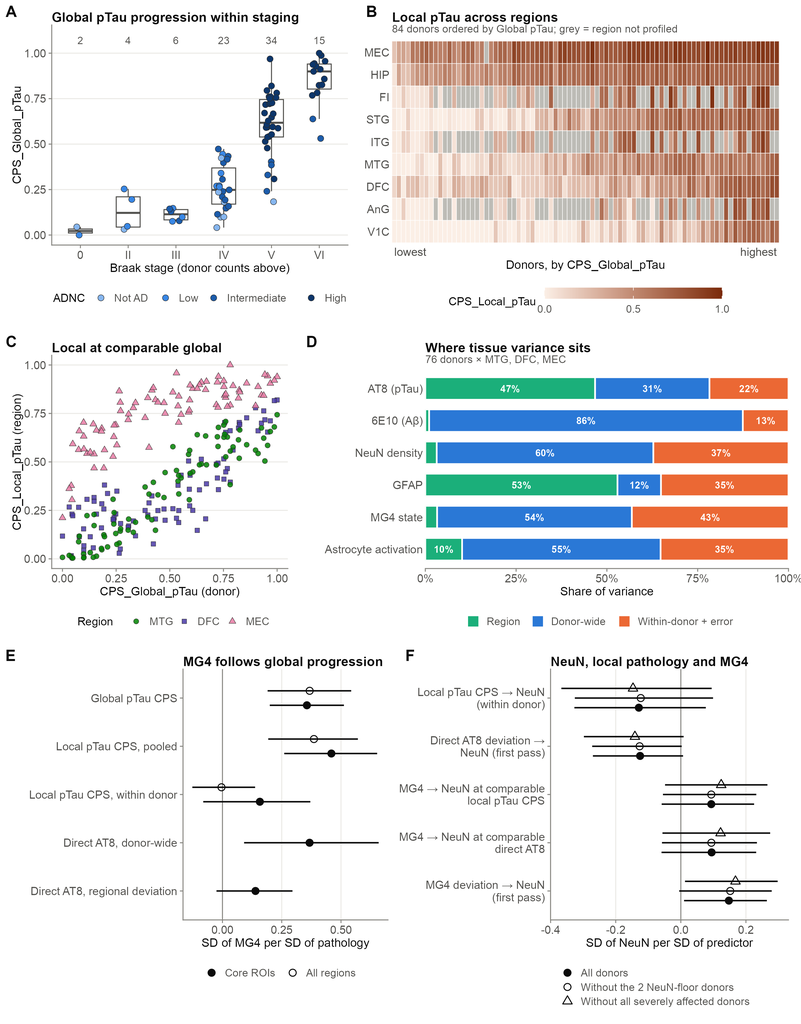

**Figure 1.** Disease progression and regional tissue response, all SEA-AD donors (ACT and ADRC). **A** Released `CPS_Global_pTau` by Braak stage (no donor at stage I), fill = ADNC; boxes are quartiles. **B** Released `CPS_Local_pTau` for every donor × region, donors ordered by Global pTau and regions by median local pTau; AnG, FI and ITG were profiled only in the 43 AD-spectrum donors. **C** Local against global pTau progression in MTG, DFC and MEC (donor × ROI points). Local is not a residual of global, and no reference line is implied. **D** Variance components of direct QNP and molecular measures over 76 donors with all three core ROIs (first pass): region, donor-wide level, and within-donor regional variation plus measurement error. **E** MG4 (SD units) against pathology in separate models: global pTau CPS; local pTau CPS pooled and within donor (donor fixed effects); first-pass direct-AT8 donor-wide and regional-deviation terms. Core ROIs: 244 rows, 84 donors; all regions: 497 rows. **F** NeuN (within-ROI normal score) within donors against local pTau CPS or direct AT8, and MG4 at comparable local pathology, with the two donors with near-zero NeuN immunoreactivity or all 11 severely affected donors removed. NeuN density measures NeuN-immunoreactive profiles, not absolute neuron number. Donor-cluster bootstrap 95% CI (2000 resamples); donors are the resampling unit. Associations are cross-sectional and not causal; QNP and snRNA-seq come from the same ROI, not the same microscopic field.

## 4. Longitudinal cognitive phenotypes (ACT, 69 donors)

### 4.1 Released variables: documentation, observations and open questions

The harmonized workbook is a single sheet with no notes, codebook or methods text. The SEA-AD data dictionary covers only `Last CASI Score` and its interval.

One focused search of the accessible methods literature found two usable sources:

- **The harmonization pipeline.** It is described in Mukherjee et al. (2023, *Neuropsychology* 37: 409, doi 10.1037/neu0000835; full text not accessible here) and, in methods text, in the cohort-pooled genome-wide study of these scores (*Mol Neurodegener* 2023, PMC10286470).
- **The dataset paper.** The Gabitto et al. preprint cites Crane et al. (2022, *Alzheimer’s & Dementia* 18:e064534) for the domain scores. Crane and Mukherjee are listed data contributors of the SEA-AD metadata release. The preprint’s full Methods were not accessible.

Cognitive-variable provenance: what is documented, what is observed in these data, and what remains open. Slope definitions are not inferred from column names.

| Item | Documented (source) | Observed here | Unresolved |
| --- | --- | --- | --- |
| `MEM_E`, `EXF_E`, `LAN_E`, `VSP_E` | Harmonized, co-calibrated domain scores from confirmatory factor analysis (Mplus); anchor items shared across cohorts put studies on one metric; single-factor or bifactor model chosen per study; item … | ACT visit-level SD 0.43–0.57 and positive means, so scores are not standardized to this cohort | Reference sample and target mean/SD of the metric; which calibration release produced this file |
| `*_E_SE` | Co-calibrated scores carry a per-score standard error; the pooled genetic study excluded scores with SE > 0.6 (PMC10286470) | Present at visit level; see the SE table below | Whether SEA-AD applied any SE-based exclusion |
| Domain slopes `slope_zmem0`, `slope_zexf0`, `slope_zlan0`, `slope_zvsp0` | None located. The dataset paper reports memory ‘slopes’ (−0.15 in severely affected vs −0.11 in ADNC 3 donors) without a method in the accessible text | Donor-constant; memory tracks the per-year MEM_E rate; executive/language shrunk toward the mean (table below) | Model, time scale, the meaning of ‘z’ and ‘0’ in the names, and uncertainty |
| `slope_zcasi_irt0` | None located | Correlates 0.91 with the memory slope; no visit-level CASI-IRT released | Model, units, uncertainty |
| `CASI_bifactor_scores` | – | Absent from every local file | Whether it exists in another release |

Visit-level score standard errors in ACT. The SE > 0.6 column applies the exclusion rule of the pooled genetic study only descriptively; no visit is excluded here.

| Score | Visits with SE | Median SE | Share SE > 0.6 |
| --- | --- | --- | --- |
| MEM_E | 545 | 0.43 | 0% |
| EXF_E | 545 | 0.54 | 5% |
| LAN_E | 545 | 0.56 | 39% |
| VSP_E | 539 | 0.86 | 96% |

**Why do 58% of visuospatial visits share one value?** The score distribution suggests an answer, though no document states it:

VSP_E in ACT: share of visits at and above the modal value (0.609) by time before death.

| Years before death | Visits | At modal value | Above modal value |
| --- | --- | --- | --- |
| 0–3 | 52 | 50% | 8% |
| 4–7 | 134 | 63% | 4% |
| 8–12 | 156 | 31% | 26% |
| > 12 | 197 | 78% | 1% |

- **Few distinct values.** ACT `VSP_E` takes 52 distinct values over 539 visits, against 262 for `MEM_E`.
- **An identical scored pattern.** The modal value 0.609 holds 58% of visits and 67 of 69 donors reach it at least once. Every modal visit carries the same SE (0.859), which is what an identical item set with an identical response pattern produces.
- **Not the scale maximum.** Only 10% of visits score above it (up to 1.20), and those carry lower SEs (median 0.76), as expected when more items were administered.
- **Empirical reading.** The pattern is **consistent with a ceiling on a small, routinely administered visuospatial item set**, with higher scores reachable only at visits with additional items. The share at the mode also varies non-monotonically with time before death, which suggests battery composition changed across ACT waves.
- **Status.** Neither the item content nor the battery history is documented in the accessible sources. This remains an empirical explanation, not a documented one. `VSP_E` and `slope_zvsp0` are kept as released, not rescaled or replaced.

**Released slopes against the visits.** Each released slope is compared with the ordinary least-squares rate of the same donor’s visits. That rate is a check only; it is never used as an outcome.

Released domain slopes against each donor’s own OLS rate (score per year of age). No standard error is released for any slope.

| Domain | Variable | Donors | r with OLS rate | Slope on OLS rate | Mean offset | SD ratio |
| --- | --- | --- | --- | --- | --- | --- |
| Memory | slope_zmem0 | 69 | 0.88 | 0.99 | -0.05 | 1.13 |
| Executive | slope_zexf0 | 69 | 0.73 | 0.46 | -0.02 | 0.64 |
| Language | slope_zlan0 | 69 | 0.73 | 0.64 | -0.03 | 0.88 |
| Visuospatial | slope_zvsp0 | 69 | 0.34 | 0.28 | -0.04 | 0.81 |

- **`slope_zmem0` (memory decline).** Behaves like a per-year `MEM_E` rate (coefficient 0.99 on the donors’ OLS rates, r 0.88), with a mean offset.
- **`slope_zexf0` and `slope_zlan0` (executive and language decline).** Shrunk toward the mean (SD ratios 0.64 and 0.88), consistent with model-based person-specific estimates.
- **`slope_zvsp0` (visuospatial decline).** Agrees poorly with the visits (r 0.34).
- **`slope_zcasi_irt0` (global decline).** An IRT-scaled CASI slope that cannot be checked against visits, since no visit-level score is released. It is the only global longitudinal rate.

The exact models, units and uncertainty of all five slopes remain **unresolved**. They are used as released, never replaced by the OLS rates, and never given assumed standard errors. Coefficients on slopes are therefore reported in SD of the released variable, not in cognitive units per year.

### 4.2 Four-domain characterization: level and rate

**Level** is the mean domain score over visits within 10 years of death (≥ 2 visits). The last visit is also shown, and the released slope is the **rate**.

Four-domain characterization, 69 ACT donors. Visit SE and SD from all ACT visits. A large share of visits at one value indicates a ceiling or coarse scale.

| Domain | Donors (visits, median [IQR]) | Visit SE / visit SD | Visits at the modal value | Last visit, median [IQR] | 10-y level, median [IQR] | Released slope, median [IQR] | ρ level vs rate | ρ rate vs last CASI |
| --- | --- | --- | --- | --- | --- | --- | --- | --- |
| Memory | 69 (7 [6–9]) | 0.43 / 0.57 | 25% | 0.10 [-0.48–0.49] | 0.46 [0.02–0.71] | -0.098 [-0.144–-0.053] | 0.72 | 0.74 |
| Executive | 69 (7 [6–9]) | 0.54 / 0.45 | 12% | -0.06 [-0.42–0.29] | 0.25 [-0.10–0.47] | -0.056 [-0.078–-0.029] | 0.57 | 0.39 |
| Language | 69 (7 [6–9]) | 0.56 / 0.43 | 38% | 0.15 [-0.25–0.51] | 0.51 [0.21–0.63] | -0.056 [-0.090–-0.033] | 0.77 | 0.60 |
| Visuospatial | 69 (7 [6–9]) | 0.86 / 0.46 | 58% | 0.61 [-0.14–0.61] | 0.42 [0.16–0.61] | -0.036 [-0.062–-0.012] | 0.79 | 0.09 |

**Grouped-trajectory diagnostic (Figure 2C).** The binned trajectories pool whichever donors were seen at each time before death. Two checks follow: how many donors feed each bin, and whether the within-donor change over each donor’s own final visits shows the same ordering.

Donors contributing a memory visit to each 2-year bin before death (the bins of Figure 2C; bins with < 5 donors are not drawn).

| Global pTau tertile | 0–2 y | 2–4 y | 4–6 y | 6–8 y | 8–10 y | 10–12 y |
| --- | --- | --- | --- | --- | --- | --- |
| low Global pTau | 2 | 22 | 26 | 26 | 21 | 22 |
| mid Global pTau | 4 | 16 | 24 | 23 | 22 | 22 |
| high Global pTau | 1 | 11 | 12 | 17 | 18 | 17 |

Within-donor memory change between each donor’s last visit and the visit closest to 4 years earlier (gap ≥ 3 years). Descriptive; not a trajectory model.

| Global pTau tertile | Donors | Last visit, years before death (median) | Within-donor MEM_E change per year, mean [IQR] |
| --- | --- | --- | --- |
| low Global pTau | 26 | 2 | -0.048 [-0.146, 0.026] |
| mid Global pTau | 24 | 2 | -0.124 [-0.255, 0.001] |
| high Global pTau | 19 | 3 | -0.259 [-0.349, -0.126] |

**Reading of the diagnostic.**

- **Thin final bins.** The last 0–2 years before death hold at most 4 donors per tertile and are not drawn. The 2–4-year bin holds 11–22.
- **Different donors in different bins.** Only 3 donors contribute to every bin from 0 to 8 years, so a fixed-donor version of the curves cannot be drawn.
- **The ordering is within-donor, not just composition.** Over each donor’s own final ~4 years, memory declines faster in the higher tertiles (-0.048, -0.124 and -0.259 per year, low to high). The separation of the grouped curves reflects within-donor decline, not only who was seen when.
- **The late steepening is not an individual transition.** The apparent late steepening of the high-tertile curve mixes donors with different visit timing, and high-tertile donors’ last visits fall earlier. It is not read as an individual-level acceleration or change point.

### 4.3 Cognitive phenotypes and global pTau progression

Each phenotype (standardized) is modelled on `CPS_Global_pTau` (per 0.1), age, sex, education and assessment timing:

- the CASI-to-death interval for terminal CASI;
- years from the last harmonized visit to death for the levels and slopes.

That makes ten single-exposure models. The **co-pathology sensitivity** adds LATE-NC 2–3 and severe arteriolosclerosis on identical donors. Braak and ADNC are shown descriptively only and never enter these models alongside CPS.

Each phenotype (SD units) on CPS_Global_pTau per 0.1, adjusted for age, sex, education and assessment timing; OLS 95% CI; one row per ACT donor. Levels need ≥ 2 visits within 10 years of death.

| Phenotype | Kind | Donors | SD per 0.1 Global pTau [95% CI] | Model R² | + co-pathology |
| --- | --- | --- | --- | --- | --- |
| Terminal CASI | Terminal | 69 | -0.24 [-0.31, -0.16] | 0.44 | -0.22 [-0.30, -0.14] |
| Global slope (CASI-IRT) | Rate | 69 | -0.21 [-0.29, -0.13] | 0.41 | -0.18 [-0.26, -0.10] |
| Memory rate | Rate | 69 | -0.20 [-0.28, -0.12] | 0.39 | -0.17 [-0.25, -0.09] |
| Executive rate | Rate | 69 | -0.06 [-0.15, +0.03] | 0.20 | -0.02 [-0.12, +0.07] |
| Language rate | Rate | 69 | -0.15 [-0.23, -0.07] | 0.35 | -0.13 [-0.21, -0.05] |
| Visuospatial rate | Rate | 69 | +0.01 [-0.08, +0.10] | 0.20 | +0.01 [-0.09, +0.10] |
| Memory level | Level | 68 | -0.15 [-0.23, -0.07] | 0.40 | -0.12 [-0.20, -0.04] |
| Executive level | Level | 68 | -0.07 [-0.16, +0.02] | 0.24 | -0.05 [-0.15, +0.04] |
| Language level | Level | 68 | -0.11 [-0.19, -0.03] | 0.33 | -0.10 [-0.18, -0.02] |
| Visuospatial level | Level | 68 | +0.04 [-0.05, +0.13] | 0.25 | +0.03 [-0.06, +0.13] |

Descriptive context: cognitive phenotypes (median [IQR]) by Braak stage in ACT. No model.

| Braak stage | Donors | Last CASI | Memory rate | Executive rate | Language rate | Visuospatial rate |
| --- | --- | --- | --- | --- | --- | --- |
| 0–III | 12 | 97 [91–98] | -0.056 [-0.086–-0.013] | -0.036 [-0.056–-0.016] | -0.030 [-0.041–-0.016] | -0.033 [-0.045–-0.024] |
| IV | 19 | 93 [88–96] | -0.060 [-0.101–-0.047] | -0.043 [-0.077–-0.020] | -0.038 [-0.066–-0.026] | -0.038 [-0.075–-0.012] |
| V | 31 | 84 [78–91] | -0.123 [-0.168–-0.089] | -0.058 [-0.076–-0.037] | -0.065 [-0.106–-0.049] | -0.037 [-0.066–-0.017] |
| VI | 7 | 79 [70–84] | -0.170 [-0.231–-0.099] | -0.082 [-0.119–-0.068] | -0.108 [-0.118–-0.080] | -0.009 [-0.072–-0.006] |

**Progression shape.** The linear representation was checked for the two prioritized outcomes, terminal CASI and memory rate. Mean residuals were examined by quintile of global pTau, and one nonlinear sensitivity was fitted (a quadratic term), with no spline or threshold search.

Mean residual (SD units) of the primary linear model by quintile of CPS_Global_pTau (Q1 lowest), and the single quadratic sensitivity. ACT, 69 donors.

| Outcome | Q1 | Q2 | Q3 | Q4 | Q5 | ΔR² quadratic | F-test p |
| --- | --- | --- | --- | --- | --- | --- | --- |
| Terminal CASI | -0.22 | 0.02 | 0.37 | 0.04 | -0.18 | 0.061 | 0.008 |
| Memory rate | -0.10 | -0.18 | 0.56 | -0.15 | -0.08 | 0.042 | 0.035 |

- **Terminal CASI departs from linearity.** The mid-stage residuals are positive and those at both extremes negative. A quadratic term adds ΔR² 0.061 (p 0.008). CASI is flat at low global stage, where 18 donors score ≥ 95, and falls more steeply at high stage.
- **Memory rate shows the same shape, more weakly** (ΔR² 0.042, p 0.035).
- **What this means for the linear model.** The linear coefficient is best read as the average association over the observed range. It remains the primary representation, and the direction and ranking of domains below are unaffected.
- **Where it matters.** The curvature bears on Section 5, since any feature concentrated at high stage could absorb it, so that section adds the quadratic as a sensitivity.

**Reading.** Global pTau progression separates the domains:

- **Terminal CASI:** -0.24 [-0.31, -0.16] SD per 0.1, model R² 0.44.
- **Global slope:** -0.21 [-0.29, -0.13].
- **Memory rate:** -0.20 [-0.28, -0.12].
- **Language rate:** -0.15 [-0.23, -0.07].
- **Executive rate:** -0.06 [-0.15, +0.03], weak.
- **Visuospatial rate:** unrelated (+0.01 [-0.08, +0.10]).

Rates track global pTau more closely than levels do (memory level -0.15 [-0.23, -0.07]). All estimates hold with co-pathology added.

The Braak table shows the same ordering descriptively, with wide within-stage spread in every rate.

### 4.4 Global versus anatomically matched local pTau

Only one anatomically motivated region per domain is used (not a region × domain grid):

| Domain | Region | Rationale |
| --- | --- | --- |
| Memory | MEC | entorhinal input to the hippocampal memory system |
| Executive | DFC | dorsolateral prefrontal cortex |
| Language | MTG | lateral temporal lexical-semantic cortex |
| Visuospatial | AnG | inferior parietal cortex (profiled only in the AD-spectrum donors) |

For each domain rate, two models are fitted on **identical donors**, one with global and one with matched local pTau, each alone with the same covariates. They are compared by standardized coefficient and ΔR² (local − global) with a donor bootstrap. The two are never entered together.

Domain rate on global or matched local pTau CPS, separately, on identical donors (age, sex, education, last-visit timing); donor bootstrap 95% CI (2000 resamples).

| Domain | Region | Donors | Global pTau (SD/SD) | Matched local pTau (SD/SD) | ΔR² local − global |
| --- | --- | --- | --- | --- | --- |
| Memory | MEC | 68 | -0.53 [-0.69, -0.35] | -0.38 [-0.58, -0.17] | -0.12 [-0.21, -0.01] |
| Executive | DFC | 69 | -0.15 [-0.40, +0.11] | -0.25 [-0.52, +0.01] | +0.04 [-0.02, +0.13] |
| Language | MTG | 69 | -0.41 [-0.60, -0.22] | -0.34 [-0.53, -0.12] | -0.05 [-0.09, +0.00] |
| Visuospatial | AnG | 34 | +0.07 [-0.31, +0.42] | +0.21 [-0.18, +0.56] | +0.03 [-0.05, +0.15] |

**Reading.** Global and local progression relate differently to the domains:

- **Memory decline** follows **global** pTau (-0.53 [-0.69, -0.35] SD/SD) at least as closely as MEC local pTau (-0.38 [-0.58, -0.17]; ΔR² -0.122 [-0.213, -0.007]). MEC is heavily involved early in almost every donor (Section 2), so its variation between donors is compressed. Memory decline reads as a stage-wide phenotype.
- **Executive decline** leans toward **DFC** (-0.25 [-0.52, +0.01]) over global (-0.15 [-0.40, +0.11]; ΔR² +0.036 [-0.018, +0.133]). This is the one domain where the matched region edges out global stage, as the first pass found with direct AT8, but the difference is imprecise.
- **Language** follows global (-0.41 [-0.60, -0.22]) at least as closely as MTG (-0.34 [-0.53, -0.12]).
- **Visuospatial** is unrelated to either (AnG, n = 34), which is unsurprising given its ceiling and poorly defined slope.

None of these comparisons shows that a region’s pathological distribution measures circuit function. They show which progression representation carries the domain’s association.

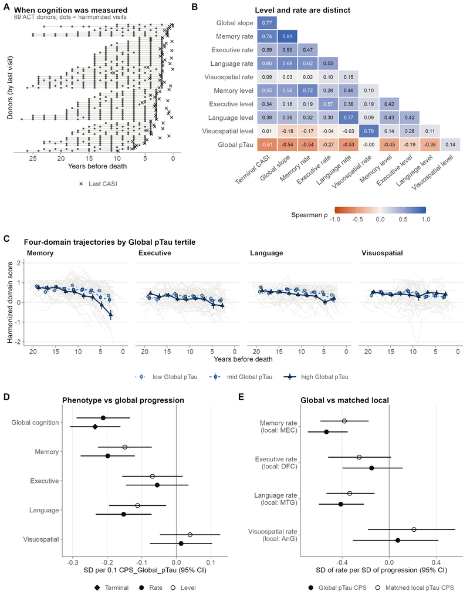

**Figure 2.** Longitudinal cognitive phenotypes in the 69 ACT donors (all with ≥ 3 harmonized visits and all five released slopes; ADRC excluded). **A** Timing of every harmonized visit (dots) and the last CASI (×) relative to death; whole-year ages add ±1 year of rounding. **B** Spearman correlations among terminal CASI, the released global and domain slopes (rate), 10-year domain levels, and CPS_Global_pTau. **C** Memory, executive, language and visuospatial trajectories; grey lines are donors, coloured lines 2-year-bin means ± SE within CPS_Global_pTau tertiles (all-donor cuts), shown where a bin holds ≥ 5 donors, so the final 0–2 years are not drawn; bins pool different donors and are not individual curves, and late steepening is not an individual transition (within-donor diagnostic in Section 4.2). Visuospatial scores sit mostly at one value (Section 4.1). **D** Each phenotype (SD) on CPS_Global_pTau per 0.1, adjusted for age, sex, education and assessment timing; OLS 95% CI. **E** Each domain rate on global pTau or on one anatomically matched local pTau (memory–MEC, executive–DFC, language–MTG, visuospatial–AnG), fitted separately on identical donors (AnG n = 34); donor bootstrap 95% CI. Released slopes have no codebook or standard errors and behave like model-based estimates (Section 4.1). Associations are cross-sectional in tissue and not causal.

## 5. Heterogeneity at comparable global progression

This section asks whether donors at the same `CPS_Global_pTau` but with different cognition differ in regional involvement or tissue response. The design is continuous and at donor level, with no resilience threshold and no matched cutoffs.

**Model.** Each prespecified feature, standardized and one at a time, is added to

`phenotype ~ CPS_Global_pTau + age + sex + education + timing + feature`

**Outcomes:** terminal CASI and memory and executive rates, in SD units.

**Features:**

- local pTau in MEC and in DFC, the memory- and executive-matched regions;
- donor-wide direct AT8;
- donor-wide MG4;
- donor-wide NeuN;
- donor-wide astrocyte activation.

A local-pTau coefficient reads as *involvement of that region beyond the donor’s global pTau stage*. It does not treat local as a residual or as an independent exposure; its collinearity with global progression is tabulated below. Sensitivity: add LATE-NC 2–3 and severe arteriolosclerosis on identical donors.

Feature (per SD) added to phenotype ~ CPS_Global_pTau + age + sex + education + timing; outcomes in SD; OLS 95% CI; one row per ACT donor; nested models on identical donors within each variant. The NeuN-floor variant removes the two donors with near-zero NeuN immunoreactivity (Section 3.4). The quadratic variant allows curvature in global pTau (Section 4.3).

| Feature | Model | Terminal CASI | Memory rate | Executive rate |
| --- | --- | --- | --- | --- |
| Local pTau CPS, MEC | + LATE-NC 2–3 + severe arteriolosclerosis | +0.12 [-0.21, +0.44] | +0.03 [-0.31, +0.36] | +0.30 [-0.07, +0.66] |
| Local pTau CPS, MEC | + quadratic global pTau | -0.19 [-0.59, +0.20] | -0.23 [-0.64, +0.18] | +0.54 [+0.08, +1.01] |
| Local pTau CPS, MEC | Primary | +0.14 [-0.18, +0.46] | +0.07 [-0.27, +0.40] | +0.35 [-0.02, +0.72] |
| Local pTau CPS, MEC | Without the 2 NeuN-floor donors | +0.14 [-0.19, +0.47] | +0.07 [-0.27, +0.41] | +0.35 [-0.03, +0.73] |
| Local pTau CPS, DFC | + LATE-NC 2–3 + severe arteriolosclerosis | -0.42 [-0.73, -0.12] | -0.31 [-0.64, +0.01] | -0.39 [-0.75, -0.03] |
| Local pTau CPS, DFC | + quadratic global pTau | -0.25 [-0.60, +0.10] | -0.11 [-0.49, +0.27] | -0.45 [-0.89, -0.01] |
| Local pTau CPS, DFC | Primary | -0.40 [-0.70, -0.09] | -0.26 [-0.59, +0.07] | -0.34 [-0.71, +0.04] |
| Local pTau CPS, DFC | Without the 2 NeuN-floor donors | -0.40 [-0.71, -0.10] | -0.28 [-0.61, +0.04] | -0.31 [-0.68, +0.07] |
| Donor-wide direct AT8 | + LATE-NC 2–3 + severe arteriolosclerosis | -0.57 [-1.14, +0.01] | -0.38 [-0.98, +0.21] | -0.15 [-0.82, +0.52] |
| Donor-wide direct AT8 | + quadratic global pTau | -0.55 [-1.07, -0.03] | -0.28 [-0.85, +0.29] | +0.08 [-0.60, +0.76] |
| Donor-wide direct AT8 | Primary | -0.43 [-0.98, +0.12] | -0.18 [-0.76, +0.40] | +0.08 [-0.58, +0.75] |
| Donor-wide direct AT8 | Without the 2 NeuN-floor donors | -0.43 [-0.99, +0.12] | -0.19 [-0.77, +0.39] | +0.10 [-0.57, +0.76] |
| Donor-wide MG4 | + LATE-NC 2–3 + severe arteriolosclerosis | -0.16 [-0.39, +0.07] | -0.12 [-0.37, +0.12] | -0.21 [-0.47, +0.05] |
| Donor-wide MG4 | + quadratic global pTau | -0.13 [-0.36, +0.09] | -0.13 [-0.37, +0.11] | -0.19 [-0.45, +0.07] |
| Donor-wide MG4 | Primary | -0.16 [-0.39, +0.08] | -0.14 [-0.39, +0.10] | -0.21 [-0.48, +0.05] |
| Donor-wide MG4 | Without the 2 NeuN-floor donors | -0.14 [-0.38, +0.09] | -0.14 [-0.38, +0.11] | -0.22 [-0.49, +0.04] |
| Donor-wide NeuN | + LATE-NC 2–3 + severe arteriolosclerosis | +0.22 [+0.03, +0.42] | +0.28 [+0.08, +0.48] | -0.07 [-0.31, +0.17] |
| Donor-wide NeuN | + quadratic global pTau | +0.16 [-0.03, +0.35] | +0.19 [-0.01, +0.40] | -0.11 [-0.35, +0.14] |
| Donor-wide NeuN | Primary | +0.21 [+0.01, +0.40] | +0.23 [+0.02, +0.43] | -0.10 [-0.34, +0.14] |
| Donor-wide NeuN | Without the 2 NeuN-floor donors | +0.18 [-0.02, +0.38] | +0.25 [+0.03, +0.46] | -0.10 [-0.35, +0.16] |
| Donor-wide astrocyte activation | + LATE-NC 2–3 + severe arteriolosclerosis | -0.16 [-0.39, +0.06] | -0.08 [-0.32, +0.16] | -0.13 [-0.38, +0.13] |
| Donor-wide astrocyte activation | + quadratic global pTau | -0.17 [-0.38, +0.05] | -0.08 [-0.31, +0.15] | -0.17 [-0.41, +0.08] |
| Donor-wide astrocyte activation | Primary | -0.19 [-0.41, +0.03] | -0.09 [-0.33, +0.14] | -0.19 [-0.44, +0.06] |
| Donor-wide astrocyte activation | Without the 2 NeuN-floor donors | -0.19 [-0.41, +0.04] | -0.09 [-0.33, +0.14] | -0.19 [-0.45, +0.06] |

Collinearity of each feature with global pTau progression (ACT donors).

| Feature | ACT donors | ρ with CPS_Global_pTau |
| --- | --- | --- |
| Local pTau CPS, MEC | 68 | 0.81 |
| Local pTau CPS, DFC | 69 | 0.72 |
| Donor-wide direct AT8 | 68 | 0.94 |
| Donor-wide MG4 | 62 | 0.39 |
| Donor-wide NeuN | 68 | -0.15 |
| Donor-wide astrocyte activation | 62 | 0.05 |

**Reading.** At comparable global pTau progression:

- **DFC involvement and terminal CASI: not robust to curvature.** Donors with more DFC involvement have lower terminal CASI in the linear model (-0.40 [-0.70, -0.09] SD per SD). Once global pTau enters quadratically it attenuates to -0.25 [-0.60, +0.10]. DFC involvement rises mainly at high stage, where CASI falls fastest (Section 4.3), so this association is partly curvature in global progression, not regional involvement.
- **The executive pattern is regional and consistent in direction, but imprecise.** Its primary intervals just reach zero and clear it only once curvature is allowed. More DFC involvement goes with faster executive decline (-0.34 [-0.71, +0.04]; with the quadratic -0.45 [-0.89, -0.01]). Relatively MEC-predominant tau goes with slower executive decline (+0.35 [-0.02, +0.72]; with the quadratic +0.54 [+0.08, +1.01]). MEC involvement beyond global stage is unrelated to terminal CASI (+0.14 [-0.18, +0.46]).
- **Consistency across representations.** This matches the first-pass MEC-vs-neocortex AT8 gradient and the executive–DFC association of Section 4.4, on released rather than direct measures.
- **Direct donor-wide AT8** (-0.43 [-0.98, +0.12]) adds less beyond global pTau than it did beyond the Gabitto MTG CPS (Section 6). The released global pTau stage already captures most of the multiregional tau the first pass found missing from the MTG CPS.
- **Donor-wide NeuN: associated, but not separable from the severely affected phenotype.**
  - **Primary:** higher donor-wide NeuN goes with better terminal CASI (+0.21 [+0.01, +0.40]) and slower memory decline (+0.23 [+0.02, +0.43]). It is nearly independent of global pTau (ρ -0.15).
  - **Without the two NeuN-floor donors:** memory rate is unchanged (+0.25 [+0.03, +0.46]).
  - **Without all 8 severely affected ACT donors:** +0.16 [-0.07, +0.38] and +0.19 [-0.06, +0.44], both intervals including zero.
  - **With curvature in global pTau:** +0.19 [-0.01, +0.40].

  The release describes these donors as having reduced NeuN labelling and steeper late memory decline (Section 3.4). This association therefore cannot be distinguished from that phenotype, and it is not carried forward as an independent tissue-integrity correlate of resilience.
- **Molecular response adds nothing clear.** Donor-wide MG4 (-0.16 [-0.39, +0.08]) and astrocyte activation show no clear association beyond global stage.
- **Co-pathology** leaves the pattern intact.
- **Collinearity** is substantial (ρ with global pTau up to 0.94), so these are estimates of regional *pattern* at a given stage, with wide intervals.

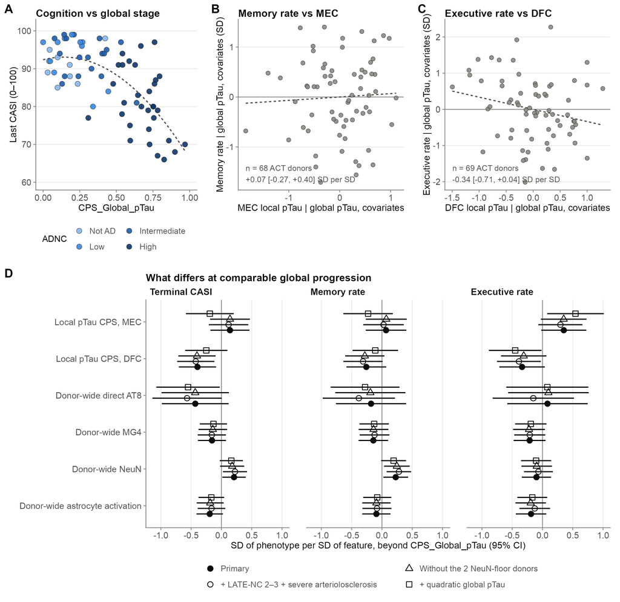

**Figure 3.** Regional involvement and tissue response among ACT donors at comparable global pTau progression. **A** Last CASI against CPS_Global_pTau (fill = ADNC; dashed descriptive quadratic fit, reflecting the curvature found in Section 4.3) for the 69 ACT donors: wide spread at every stage. **B, C** Added-variable plots for the two prespecified anatomical pairings: memory rate against MEC local pTau, and executive rate against DFC local pTau, each residualized on CPS_Global_pTau, age, sex, education and last-visit timing. **D** Each feature (per SD) added alone to phenotype ~ CPS_Global_pTau + age + sex + education + timing, for terminal CASI and the released memory and executive rates (SD units); filled = primary, open circle = + LATE-NC 2–3 and severe arteriolosclerosis, triangle = without the two donors with near-zero NeuN immunoreactivity, square = + quadratic global pTau (Section 4.3); OLS 95% CI; 60–69 donors per estimate (MG4 and astrocyte require all three core ROIs). A local-pTau coefficient describes regional involvement at a given global stage; global and local are collinear (ρ up to 0.94) and are not independent exposures. Cross-sectional associations; not causal; regional pathological distribution is not a measure of circuit function.

## 6. First-pass analyses conditioned on the Gabitto MTG CPS (retained, not extended)

These results come from this notebook’s first pass and are kept for continuity. All of them condition on `SpecimenMetadata.csv`’s MTG-fitted CPS, and none is repeated with it here.

**Terminal versus longitudinal resilience, and multiregional features beyond the MTG CPS**

First-pass results, recomputed unchanged from notebook 04’s CASI model and the Gabitto MTG CPS.

| Result | Value |
| --- | --- |
| Terminal residual vs pathology-adjusted memory decline (ρ) | 0.67 |
| Terminal residual vs pathology-adjusted executive decline (ρ) | 0.30 |
| Donor-wide direct AT8 beyond MTG CPS (CASI points per SD) | -5.0 [-7.4, -2.5] |
| Donor-wide MG4 beyond MTG CPS (CASI points per SD) | -2.2 [-4.2, -0.2] |
| Donor-wide MG4 beyond MTG CPS + donor-wide AT8 | -1.4 [-3.4, +0.6] |

First-pass conclusions, still standing:

- **Terminal vs longitudinal phenotypes.** Pathology-adjusted memory decline largely reproduces notebook 04’s terminal residual, while executive decline is a partly separate axis.
- **Multiregional tau.** At fixed MTG CPS, donor-wide direct AT8 is associated with worse terminal CASI, and MG4’s cognitive association weakens once that multiregional tau is included.
- **Matched pairs.** Matching on the three-region AT8 profile narrowed matched CASI differences, and the MG4/NeuN differences in CPS-matched pairs reversed under profile matching. Pairs were illustrative only.

Section 5 shows that the released global pTau stage absorbs much of the multiregional tau that the MTG CPS missed.

## 7. Synthesis

**1. What global and regional progression explain about cognition.**

- **Global pTau stage** carries most of the pathology–cognition association:
  - terminal CASI -0.24 [-0.31, -0.16] SD per 0.1;
  - global slope -0.21 [-0.29, -0.13];
  - memory rate -0.20 [-0.28, -0.12];
  - language rate -0.15 [-0.23, -0.07].

  These are robust to co-pathology. Terminal CASI and memory rate are concave in global stage (flat with a CASI ceiling early, steeper late). The linear estimate is an average association.
- **Conventional staging is too coarse to stand in for progression.** Braak V and High ADNC each span most of the global range (32 of 34 Braak V donors overlap the Braak IV or VI range).
- **Matched regions add nothing for memory or language** beyond global stage (memory: global -0.53 [-0.69, -0.35]).

**2. What remains associated with cognition at comparable progression.**

- **Executive decline, the one regionally structured phenotype:**
  - faster with DFC involvement (-0.45 [-0.89, -0.01] with curvature allowed);
  - slower with MEC-predominant tau (+0.54 [+0.08, +1.01]).

  The direction holds across representations (direct AT8 in the first pass, released local pTau here) and under co-pathology and curvature. The primary linear intervals just reach zero, so the estimate is imprecise.
- **DFC–terminal CASI does not survive curvature** in global stage (-0.25 [-0.60, +0.10]).
- **Donor-wide NeuN** is associated with slower memory decline, but it cannot be separated from the published severely affected phenotype (Section 5).
- **Donor-wide MG4 and astrocyte activation** add nothing clear.

**3. What MG4 and NeuN currently support biologically.**

- **MG4** is a donor-level microglial state that scales with global pTau stage (+0.36 [+0.20, +0.51] SD/SD). It is not a regional one (within-donor +0.16 [-0.08, +0.37]), and it carries no cognitive information beyond stage. It is a marker of disease stage, not an established protective or harmful factor.
- **NeuN immunoreactive density** is modestly lower where local pTau is higher within donors (-0.13 [-0.33, +0.08], interval reaching zero). MG4 at comparable local pathology is at most weakly positive for it (+0.09 [-0.06, +0.23]).
- **The two donors with near-zero NeuN** show a severe neuronal phenotype: reduced NeuN immunoreactivity, and low neuronal representation in snRNA-seq from donors defined partly by poor nuclei QC. Absolute neuronal loss is neither established nor excluded. NeuN density measures NeuN-immunoreactive profiles, not neuron number or synaptic integrity.

**4. Which aspects of the cognitive measurements remain uncertain.**

- **Domain scores.** Documented as co-calibrated CFA/IRT scores with per-score SEs. Their reference mean/SD and the calibration release used here are not documented.
- **Slopes.** No accessible source documents the model, time scale, units or uncertainty of any released slope, so associations are reported in SD of the released variable.
- **Visuospatial.** Dominated by a single scored pattern (58% of visits), empirically consistent with a ceiling on a small item set. The item content and battery history are undocumented.
- **Visit timing.** Whole-year ages, a thin final two years before death, and grouped curves that pool different donors limit any claim about terminal acceleration.

**5. Variables ready for morphology integration.**

| Block | Variable | Status |
| --- | --- | --- |
| Global progression | `CPS_Global_pTau` (donor), with a quadratic term as sensitivity | ready; principal cognition covariate |
| Regional progression | `CPS_Local_pTau` in DFC and MEC, conditional on global stage; direct AT8 normal scores for tissue coupling | ready; DFC/MEC for executive decline |
| Staging context | Braak, ADNC | descriptive only |
| Cognition (ACT) | terminal CASI; `slope_zmem0`, `slope_zexf0`, `slope_zlan0`, `slope_zcasi_irt0` as released | ready, with provenance caveats; `slope_zvsp0` not recommended |
| Molecular | donor-wide MG4 competitive score (astrocyte activation complementary) | ready as a stage-linked covariate or modifier, not a regional exposure |
| Tissue | NeuN normal score, with the near-zero-immunoreactivity flag and the published severely affected flag for sensitivity | ready as a tissue reference; not an independent resilience correlate |
| Sensitivity covariates | LATE-NC 2–3, severe arteriolosclerosis | ready |

The first morphology tests these results support are regional morphometric deviation against regional pTau deviation within donors, and DFC versus MEC morphology against executive decline at fixed global stage.

**Validation checks run during rendering**

Assertions. A failed assertion stops the render.

| Check | Result |
| --- | --- |
| Donor × ROI keys unique after QNP + molecular + released CPS join | asserted |
| Released CPS unique per donor × region; Global constant within donor; no missing value | asserted |
| Cognition set = 69 ACT donors; ADRC never modelled | asserted |
| Released slopes constant within donor; used as released | asserted |
| Nested models on identical donors (co-pathology; feature additions; global vs local comparisons) | asserted |
| Every bootstrap resample fitted | asserted |
| Donors without complete core QNP: H20.33.034 | reported, not imputed |
| Severely affected flag used only as an exclusion sensitivity, never as a model term | by construction |
| Linear vs quadratic global pTau fits on identical donors | asserted |
| Every modal VSP_E visit carries one identical SE | asserted |

Inputs read by this notebook (read-only; nothing under data/ is written).

| File | md5 |
| --- | --- |
| 6a4579d1d67150b0e69ad044_sea-ad-quantitative-neuropathology-063026.xlsx | 8b458c3a133cacd3524b75844c04a810 |
| 68debdfdd1b8e9f8fd64dab0_sea-ad_cohort_donor_metadata_072524.xlsx | 38ca87641dbd36cfa88230b6c184200b |
| SpecimenMetadata.csv | f186e0df123a344e304aa54565a2db68 |
| 68debdfd4748b7546943a7b4_sea-ad_cohort_harmonized_cognitive_scores_20241213.xlsx | e023e928e7b2029cdc8ebed8ca4703ad |
| molecular_state_analysis_table.csv | 7c6d62f0d05c7dae720e059105fae85e |
| Global_and_Local_CPS.20260105.csv | 5ccf5b9610ad2989aee730f2bed0ead4 |
| supertype_abundances_by_library.csv | 134ab94ed15d49f88612c6471122542e |
| row_state_scores.csv | 0604b5243ca2fb0c76729b4af5bcfb4f |